# Variational Encoder Fitting Confirmatory SDEs

2026-09-14

This tutorial implements variational autoencoders (VAEs) estimating a bivariate stochastic differential equation based on the Ornstein-Uhlenbeck (OU) model across two bursts, with burst-specific set point and drift coefficients – specifically coupling coefficients, that are moderated by person-specific covariates. Parameter estimates returned by two versions of VAE, the states-based VAE and filtering-based VAE, are compared to the true values used in generation of the simulated data.

If you find this code helpful, please cite:

```
@article{Chow26a,
  title={It's About Time -- Intensive Longitudinal Modeling with Machine Learning Methods},
  author={Chow, {Sy-Miin}},
  journal={Multivariate Behavioral Research},
  year={2026},
  note={under review}
}
```

## 0. Getting started

Before running any of the code in this tutorial, please check out the README file and install the required R packages. If you are hoping to use `Hyperopt` to run hyperparameter tuning in Python, then do set up the Python environment as explained in the README file.

## 1. Simulate data

```r
library(torch)
```

```r
library(ggplot2)
library(jsonlite)
library(dplyr)
library(readr)

source("../../HelperFunctions/aux_vae_sde_functions_cleaned.R")

NNow    = 500
TmaxNow = 300
TminNow = 250

Tend = 30
r = 1

  seed_num <- 1234 + (r - 1)

  dat <- simulate_burst_ou_mixed2(
    N    = NNow,
    Tmin = TminNow,
    Tmax = TmaxNow,
    seed = seed_num,
    Tend = Tend
  )

  # FIXED: set.seed() here. torch_manual_seed() does not seed R's RNG, so the
  # train/test split was not reproducible -- and that split is written into the
  # JSON and reused by the Python implementation, so both languages were
  # fitting a split that changed on every run.
  set.seed(seed_num)

  idx       <- sample(seq_len(NNow))
  train_idx <- idx[1:round(0.8 * NNow)]
  test_idx  <- idx[(round(0.8 * NNow) + 1):NNow]

  save_simdata(
    sim       = dat,
    train_idx = train_idx,
    test_idx  = test_idx,
    data_file = paste0("../Python/MCburst_long_run", r, ".csv"),
    info_file = paste0("../Python/MCburst_info_run", r, ".json")
  )
```

### 2. Create Torch tensors

```r
#Q matrix
Q <- torch_tensor(
  matrix(
    c(
      1, 0,
      0, 1
    ),
    nrow = 2,
    byrow = TRUE
  ),
  dtype = torch_float()
)

# Outcome 1: binary
# Outcome 2: continuous

Y_train <- torch_stack(
  list(
    dat$Y_obs[train_idx,,1],
    dat$Y_obs[train_idx,,2]
  ),
  dim = 3
)


Y_test <- torch_stack(
  list(
    dat$Y_obs[test_idx,,1],
    dat$Y_obs[test_idx,,2]
  ),
  dim = 3
)

M_train <- torch_stack(
  list(
    dat$M[train_idx,,1],
    dat$M[train_idx,,2]
  ),
  dim = 3
)

M_test <- torch_stack(
  list(
    dat$M[test_idx,,1],
    dat$M[test_idx,,2]
  ),
  dim = 3
)

#Irregularly spaced time stamps
times_train <- torch_tensor(dat$times[train_idx,],
                            dtype = torch_float())
times_test <- torch_tensor(dat$times[test_idx,],
                           dtype = torch_float())

#Indicator of padded data (to make maxT the same for all)
#1 = Observed data; 0 = padded data
time_mask_train <- torch_tensor(dat$time_mask[train_idx,],
                                dtype = torch_float())
time_mask_test <- torch_tensor(dat$time_mask[test_idx,],
                               dtype = torch_float())

# ---- Check dimensions ----
Y_train$size()
```

```
## [1] 400 300   2
```

```r
M_train$size()
```

```
## [1] 400 300   2
```

```r
times_test$size()
```

```
## [1] 100 300
```

```r
N_train <- Y_train$size(1)
N_test <- Y_test$size(1)


X_tv <- torch_tensor(
  dat$X_tv,
  dtype = torch_float()
)

# Columns kept here define the covariate indices used below: after this
# subset, column 1 = I_b, 2 = X2, 3 = X3. ib_col / B_x_col / x_cols in
# ou_sde_param_args index INTO THIS SUBSET, not into X_tv.
X_train <- X_tv[train_idx,,c(1,2,3)]
X_test <- X_tv[test_idx,,c(1,2,3)]

n_x <- 3
```

### 3. Plot data

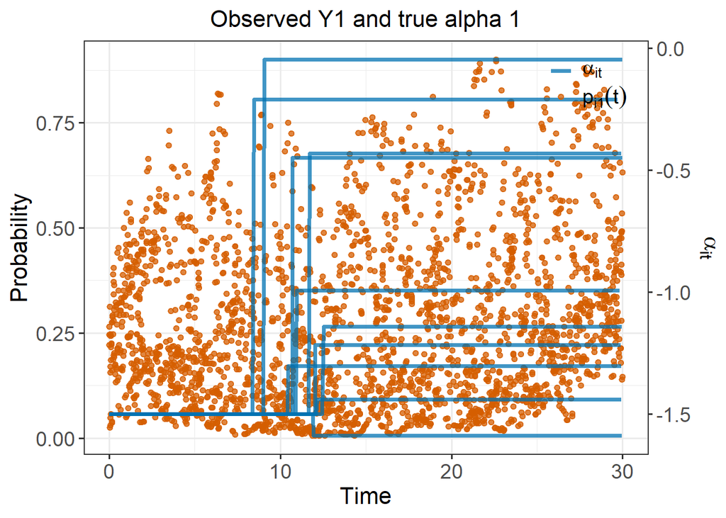

```r
y_col = 1; alpha_k = 1
plot_spaghetti_ou(
  dat = dat,
  subject_ids = sample(seq_len(dim(dat$Y_obs)[1]), 10),
  y_col = y_col,
  alpha_k = alpha_k,
  titlej = paste0("Observed Y",y_col," and true alpha ",alpha_k)
)
```

## 4. Implement and run SDE-VAE

#### SDE-VAE Model specification

We use nn_module() to define our SDE-VAE. The function nn_module is Rtorch’s mechanism for defining any differentiable computational model whose parameters will be optimized with automatic differentiation.

Within nn_module, we need to define:

| Part | What happens there |
| --- | --- |
| `initialize()` | Store fixed constants, define trainable parameters, define neural layers |
| `encode()` | Map observed data to latent variables ($z$), i.e., define $q_{\phi}(z\mid Y)$ |
| `reparameterize()` | Sample ($z$) from ($q_{\phi}(z\mid Y)$) |
| `get_sde_params()` | Transform raw SDE parameters into usable constrained SDE parameters |
| `decode()` | Map latent variables back to observed data; assemble all parameters needed to define $p_{\theta}(Y\mid z)$ & predict $Y$ |
| `forward()` | Glue everything together: $Y$ → $q_{\phi}(z\mid Y)$ → $z$ → $p_{\theta}(Y\mid z)$ |

Special cases of computational models that can be defined by nn_module include linear regression model, logistic regression model, latent variable model, state-space model, neural net, recurrent neural net, transformer, long short-term memory model, etc. This specification is contained in the function `exo_sde_vae` in `aux_vae_sde_functions_cleaned.R`.

#### Set up VAE-SDE arguments, and starting values for parameters

```r
# TRUE  means A = Q fixed
# FALSE means A entries where Q == 1 are freely estimated
isFixedLoadings <- TRUE

#Whether to use diag approximation posterior (q_{phi}(z) as N(mu, diag(Sigma)))
isDiagApprox = TRUE # Set to TRUE for all demos; symm structure didn't work as well in terms of SDE parameter recovery

#Provide starting or fixed parameter values
ou_sde_param_args <- list(
  alpha_value = c(-1, 1.5),

  alpha_shift_value = c(0.1, -0.1),

  gamma_shift_X_value = matrix(
    c(0.10, 0.10),
    nrow = 1,
    byrow = TRUE
  ),

  ib_col = 1, #Column index for Ib - first covariate
  B_x_col = 2, #Column index for X2 - covariate that moderates coupling coefs
  x_cols = 3, #Column index for x3 - covariate that moderates set point shifts

  B_value = matrix( #Starting values for drift matrix
    c(
      -0.3,  0.0,
       0.0, -0.3
    ),
    nrow = 2,
    byrow = TRUE
  ),

  gamma_B_X2_value = matrix( #Starting values for matrix of coefs of X2 on B
    c(
      0.00, 0.0,
     0.0, 0.00
    ),
   nrow = 2,
    byrow = TRUE
  ),

  #Parameter lower and upper bounds
  parBounds = list(

    B = list(
      lower = matrix(
        c(
          -1.5, -0.75,
          -0.75, -1.5
        ),
        nrow = 2,
        byrow = TRUE
      ),
      upper = matrix(
        c(
          -0.001,  0.75,
           0.75, -0.001
        ),
        nrow = 2,
        byrow = TRUE
      )
    ),

    rho = list(
      lower = -0.95,
      upper =  0.95
    ),

    gamma_B_X2 = list(
      lower = matrix(
        c(
           0.00, -0.30,
          -0.30,  0.00
        ),
        nrow = 2,
        byrow = TRUE
      ),
      upper = matrix(
        c(
          0.00, 0.30,
          0.30, 0.00
        ),
        nrow = 2,
        byrow = TRUE
      )
    )
  ),

  rho_value = 0.50, #Starting value for process noise cov matrix

  # NA for the binary outcome. init_ou_sde_params() replaces it with 1, but
  # masked_mixed_nll_multi() never touches log_sigma_y for a binary column, so
  # that element receives no gradient and stays at 1 throughout. Do not report
  # it as an estimate.
  sigma_y_value = c(NA, 0.60),
  b_value = c(0, 0), #Values of measurement intercepts (values fixed when free_b = FALSE)

  free_alpha = TRUE, #Whether to freely estimate set point intercepts
  free_alpha_shift = TRUE, #Whether to freely estimate shifts in set points at Ib=1
  free_gamma_shift_X = TRUE,#Whether to freely estimate effect of X3 on shift in set points

  free_B = TRUE, #Whether to freely estimate drift coefficients
  free_gamma_B_X2 = TRUE, #Whether to freely estimate x2 effect on coupling coefs

  free_rho = TRUE, #Whether to freely estimate process noise cor.
  free_sigma_y = TRUE,#Whether to freely estimate measurement error variance(s)
  free_b = FALSE,#Whether to freely estimate measurement intercepts

  R_a_value = .05
)
names(ou_sde_param_args)
```

```
##  [1] "alpha_value"         "alpha_shift_value"   "gamma_shift_X_value"
##  [4] "ib_col"              "B_x_col"             "x_cols"
##  [7] "B_value"             "gamma_B_X2_value"    "parBounds"
## [10] "rho_value"           "sigma_y_value"       "b_value"
## [13] "free_alpha"          "free_alpha_shift"    "free_gamma_shift_X"
## [16] "free_B"              "free_gamma_B_X2"     "free_rho"
## [19] "free_sigma_y"        "free_b"              "R_a_value"
```

```r
outcome_types <- c("binary", "gaussian") #Types of observed outcomes

traj_kl_fn <- trajectory_auxiliary_kalman_elbo_penalty #filtering-based
traj_kl_fn0 <- trajectory_kl_ou_attractor_prior        #states-based

#Argument list to implement Euler approx for CT process noise cov matrix
traj_kl_args <- list(
  include_logp0   = FALSE,
  init_state_mode = "encoder",
  transition_mean = "exact",
  transition_covariance = "euler"
  #detach_B_in_Q   = TRUE #Only for transition_covariance = "exact"
)

#Argument list to implement exact structure for CT process noise cov matrix
traj_kl_args2 <- list(
  include_logp0   = FALSE,
  init_state_mode = "encoder",
  transition_mean = "exact",
  transition_covariance = "exact",
  detach_B_in_Q   = TRUE #Only for transition_covariance = "exact"
)
```

#### Set hyperparameter values

```r
train_data <- list(
  Y         = Y_train,
  M         = M_train,
  times     = times_train,
  time_mask = time_mask_train,
  X         = X_train
)

#test_arrays -> goes to extract_exo_sde_estimates. Torch tensors, the model's inputs. No truth in it.

#forPlot_test_dat -> goes to summarize_OU_mixed_fit. R arrays, and it's the only one carrying ground truth (states, true).

test_arrays <- list(
  Y_obs     = Y_test,
  M         = M_test,
  times     = times_test,
  time_mask = time_mask_test,
  X         = X_test
)

forPlot_test_dat <- list(
  Y_obs     = dat$Y_obs[test_idx, , ],
  M         = dat$M[test_idx, , ],
  times     = dat$times[test_idx, ],
  time_mask = dat$time_mask[test_idx, ],
  states    = dat$states[test_idx, , ],
  true      = dat$true
)


# Set hyperparameters to values optimized with Hyperopt in Python earlier
best_hp <- list(
  hidden_size = 64L,
  n_layers    = 1L,
  dropout     = 0.07,
  lr          = 0.02,
  batch_size  = as.integer(round(N_train / 2))
)

cat("\nBest hyperparameters:\n")
```

```
##
## Best hyperparameters:
```

```r
print(best_hp)
```

```
## $hidden_size
## [1] 64
##
## $n_layers
## [1] 1
##
## $dropout
## [1] 0.07
##
## $lr
## [1] 0.02
##
## $batch_size
## [1] 200
```

#### Run final VAE-SDE model

```r
# Commented out and loaded pre-run Rdata file. But uncomment to run the states-based and filtering based VAEs.
# t0 = Sys.time()
# print(paste0("Starting states-based VAE!"))
# res_statesFinal <- autoRun(
#   R_a_values = c(NA),
#   kl_weights = c(.1),
#   seeds      = c(5678),
#
#   train_data = train_data,
#   test_arrays = test_arrays,
#   test_dat   = forPlot_test_dat,
#
#   Q = Q,
#   sde_param_args = ou_sde_param_args,
#
#   trajectory_kl_fn = traj_kl_fn0,
#   trajectory_kl_args = traj_kl_args,
#
#   measurement_loss_fn = masked_mixed_nll_multi,
#   measurement_loss_args = list(outcome_types = outcome_types),
#
#   best_params = best_hp,
#
#   n_epochs = 1000,
#   patience = 75,
#   out_prefix = "FinalStates",
#   keep_est = TRUE
# )
# t1a = Sys.time()-t0
#
# t0 =  Sys.time()
# print(paste0("Starting filtering-based VAE!"))
# res_filterFinal <- autoRun(
#   R_a_values = c(.05),
#   kl_weights = c(.1),
#   seeds      = c(5678),
#
#   train_data = train_data,
#   test_arrays = test_arrays,
#   test_dat   = forPlot_test_dat,
#
#   Q = Q,
#   sde_param_args = ou_sde_param_args,
#
#   trajectory_kl_fn = traj_kl_fn,
#   trajectory_kl_args = traj_kl_args,
#
#   measurement_loss_fn = masked_mixed_nll_multi,
#   measurement_loss_args = list(outcome_types = outcome_types),
#
#   best_params = best_hp,
#
#   n_epochs = 1000,
#   patience = 75,
#   out_prefix = "FinalFilter",
#   keep_est = TRUE
# )
# t1b = Sys.time()-t0
#
# save(res_statesFinal, res_filterFinal, t1a, t1b, file = "Finalres_toSave.RData")

load("Finalres_toSave.RData")
```

### 5. Inspect Results

```r
# One row per configuration: validation loss, best epoch, run time, and the
# recovery summaries.
res_statesFinal$wide
```

```
##             run_id run_index R_a kl_weight seed transition_mean
## 1 RaNA_kl0.1_s5678         1  NA       0.1 5678           exact
##   transition_covariance init_state_mode detach_B_in_Q include_logp0 status
## 1                 euler         encoder         FALSE         FALSE     ok
##   val_loss    val_y val_kl_traj best_epoch n_fit n_valid elapsed_min log_pa_hat
## 1 431.4186 256.8826     1745.36        230   320      80    59.35676  -145.8912
##   log_qa_given_y_hat aux_kl_hat loss_y_hat rmse_all_params    rmse_B
## 1           873.4281   1019.319   257.1856       0.1348418 0.2346588
##   metric_binary_logloss metric_binary_accuracy metric_binary_mean_observed
## 1             0.4887912              0.7649626                   0.2949305
##   metric_binary_mean_predicted_prob metric_continuous_rmse
## 1                         0.2866128              0.4442239
##   metric_continuous_mae metric_continuous_cor metric_continuous_mean_observed
## 1              0.353998             0.9692684                        1.751176
##   metric_continuous_mean_predicted metric_z1_cor metric_z1_rmse metric_z1_mae
## 1                         1.566312     0.8258721      0.8805916     0.6909594
##   metric_z2_cor metric_z2_rmse metric_z2_mae metric_loss_hat metric_loss_y_hat
## 1     0.9576201      0.4554176     0.3587379        359.1175          257.1856
##   metric_log_py_given_a_hat metric_log_pa_hat metric_log_qa_given_y_hat
## 1                 -257.1856         -145.8912                  873.4281
##   metric_aux_kl_hat
## 1          1019.319
```

```r
res_filterFinal$wide
```

```
##               run_id run_index  R_a kl_weight seed transition_mean
## 1 Ra0.05_kl0.1_s5678         1 0.05       0.1 5678           exact
##   transition_covariance init_state_mode detach_B_in_Q include_logp0 status
## 1                 euler         encoder         FALSE         FALSE     ok
##   val_loss     val_y val_kl_traj best_epoch n_fit n_valid elapsed_min
## 1 -75.6404 -193.8418    1182.014        388   320      80    85.16402
##   log_pa_hat log_qa_given_y_hat aux_kl_hat loss_y_hat rmse_all_params    rmse_B
## 1   -657.223           655.0025   1312.225  -205.0529       0.2740537 0.5466578
##   metric_binary_logloss metric_binary_accuracy metric_binary_mean_observed
## 1             0.3831174              0.8471016                   0.2949305
##   metric_binary_mean_predicted_prob metric_continuous_rmse
## 1                         0.2946302              0.0286941
##   metric_continuous_mae metric_continuous_cor metric_continuous_mean_observed
## 1            0.01841056             0.9998392                        1.751176
##   metric_continuous_mean_predicted metric_z1_cor metric_z1_rmse metric_z1_mae
## 1                          1.74848     0.7858364      0.9672346     0.7582163
##   metric_z2_cor metric_z2_rmse metric_z2_mae metric_loss_hat metric_loss_y_hat
## 1     0.9468472       0.473747     0.3710696       -73.83033         -205.0529
##   metric_log_py_given_a_hat metric_log_pa_hat metric_log_qa_given_y_hat
## 1                  205.0529          -657.223                  655.0025
##   metric_aux_kl_hat
## 1          1312.225
```

```r
res_statesFinal$failures
```

```r
res_filterFinal$failures
```

```r
recovery_table(res_statesFinal)
```

```
##      R_a kl_weight seed estimate.rho   error.rho
## 1.14  NA       0.1 5678    0.2408949 -0.05910515
```

```r
recovery_table(res_filterFinal)
```

```
##       R_a kl_weight seed estimate.rho  error.rho
## 1.14 0.05       0.1 5678    0.3106551 0.01065506
```

#### Make some plots to inspect the results

Plot true and estimated latent variable estimates. For states-based VAE, the latent variable estimates are based on the means of proposal distribution for the states-based VAE, and filtered estimates of the latent variables for the filtering-based VAE.

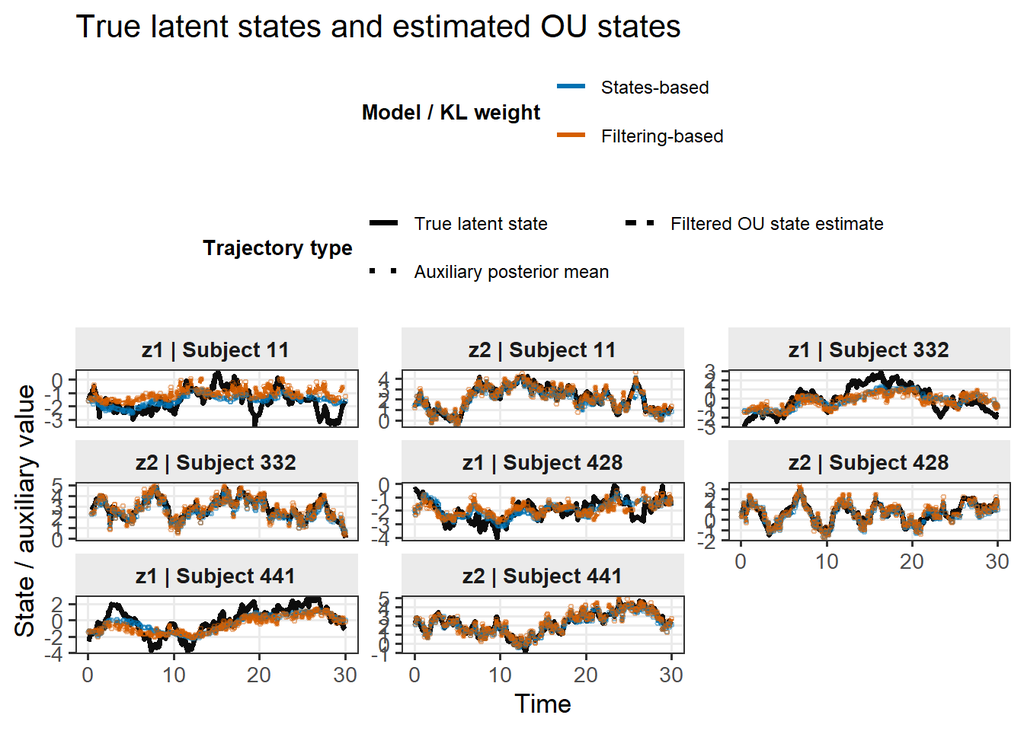

```r
pdat_ou_pred <- make_BurstOU_compare_plot_data(
  est_list     = list(res_statesFinal$est[[1]], res_filterFinal$est[[1]]),
  model_labels = c("States-based", "Filtering-based"),
  dat          = forPlot_test_dat,
  subject_ids  = test_idx,
  subjects     = test_idx[1:4], #Use a subset of subjects
  state_source = c("auxiliary_mean", "filtered")
)

plot_BurstOU_yhat_obs_latent(
  pdat = pdat_ou_pred,
  outcomes = c("z1", "z2"),
  facet_by_subject = TRUE
)
```

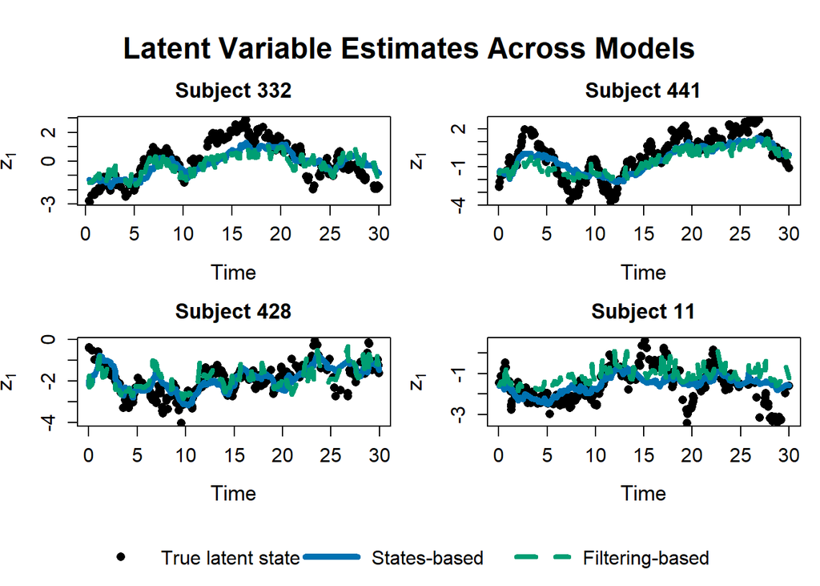

```r
plot_BurstOU_compare_yhat_latent(
  pdat = pdat_ou_pred,
  outcome = "z1",
  facet_layout = c(2, 2),
  reference_model = "States-based",
  true_point_col = "black",
  true_point_pch = 16,
  true_point_cex = 1.2,

  # font sizes
  main_cex = 1.5,
  axis_cex = 1.2,
  lab_cex = 1.3,
  strip_cex = 1.3,
  legend_cex = 1.2,

  model_cols = c(
    "States-based"    = "#0072B2",
    "Filtering-based" = "#009E73"
  ),
  model_ltys = c(
    "States-based"    = 1,
    "Filtering-based" = 2
  ),
  model_lwd = 4,
  reference_lwd = 5,
  main = "Latent Variable Estimates Across Models",
  ylab = expression(z[1]),
  legend_position = "bottom"
)
```

#### Benchmark CPU time

```r
timing <- data.frame(
  section = c("States-based", "Filtering-based"),
  minutes = round(c(as.numeric(t1a), as.numeric(t1b)) / 60, 2),
  cpu     = trimws(suppressWarnings(utils::readRegistry(
              "HARDWARE\\DESCRIPTION\\System\\CentralProcessor\\0",
              hive = "HLM"))$ProcessorNameString),
  cores   = parallel::detectCores(logical = FALSE),
  ram_gb  = round(ps::ps_system_memory()$total / 1024^3, 1)
)

timing
```

```
##           section minutes                                    cpu cores ram_gb
## 1    States-based    0.99 AMD Ryzen 7 5700G with Radeon Graphics     8   31.4
## 2 Filtering-based    0.02 AMD Ryzen 7 5700G with Radeon Graphics     8   31.4
```